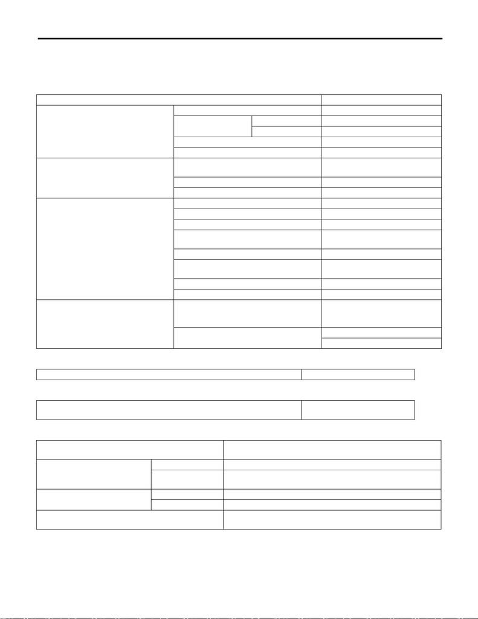

PS-2

General Description

POWER ASSISTED SYSTEM (POWER STEERING)

1. General Description

A: SPECIFICATION

1. HYDRAULIC TYPE

Steering wheel

Column assembly - steering

Steering gearbox

Model STI model

Whole system

Minimum turning radius: m (ft) 5.6 (18.4)

Steering angle

Inner wheel 36.3°±1.5°

Outer wheel 32.0°±1.5°

Steering wheel diameter: mm (in) 369 (14.53)

Lock-to-lock revolution number 2.5

Gearbox

Type

Rack & pinion type

Integral type

Backlash 0 (automatic adjusting)

Valve type Rotary valve

Power steering pump

Type Vane pump

Oil tank Installed on body

Specific discharge rate: cm

3

(cu in)/rev. 8.5 (0.519)

Relief pressure: kPa (kgf/cm

2

, psi)

8,300 — 9,000

(85 — 92, 1,203 — 1,305)

Hydraulic fluid control Engine speed sensitive

Operation flow rate: L (US qt, Imp qt)

1,000 rpm: 7.5 (7.9, 6.6)

3,000 rpm: 7.3 (7.7, 6.4)

Revolution speed range: rpm 560 — 9,600

Direction of rotation Clockwise

Power steering fluid

Description

SUBARU ATF

or

ATF DEXRON III

Capacity: L (US qt, Imp qt)

Oil tank: 0.2 (0.2, 0.2)

Whole system: 0.7 (0.7, 0.6)

Free play: mm (in) 17 (0.67)

Clearance:

Between steering wheel and cover assembly - column

mm (in) 4 — 6 (0.16 — 0.24)

Sliding resistance: N (kgf, lbf)

343 (35, 77) or less

Difference between right and left sliding resistance: 20% or less

Rack shaft play in radial direction:

mm (in)

Right-turn steering 0.4 (0.016) or less

Left-turn steering

Play in the horizontal direction: 0.6 (0.024) or less

Play in the vertical direction: 0.4 (0.016) or less

Input shaft play: mm (in)

In radial direction 0.26 (0.0102) or less

In axial direction Without play

Rotational resistance: N (kgf, lbf)

Maximum allowable value: 21 (2.14, 4.7) or less

Difference between right and left rotating resistance: 20% or less

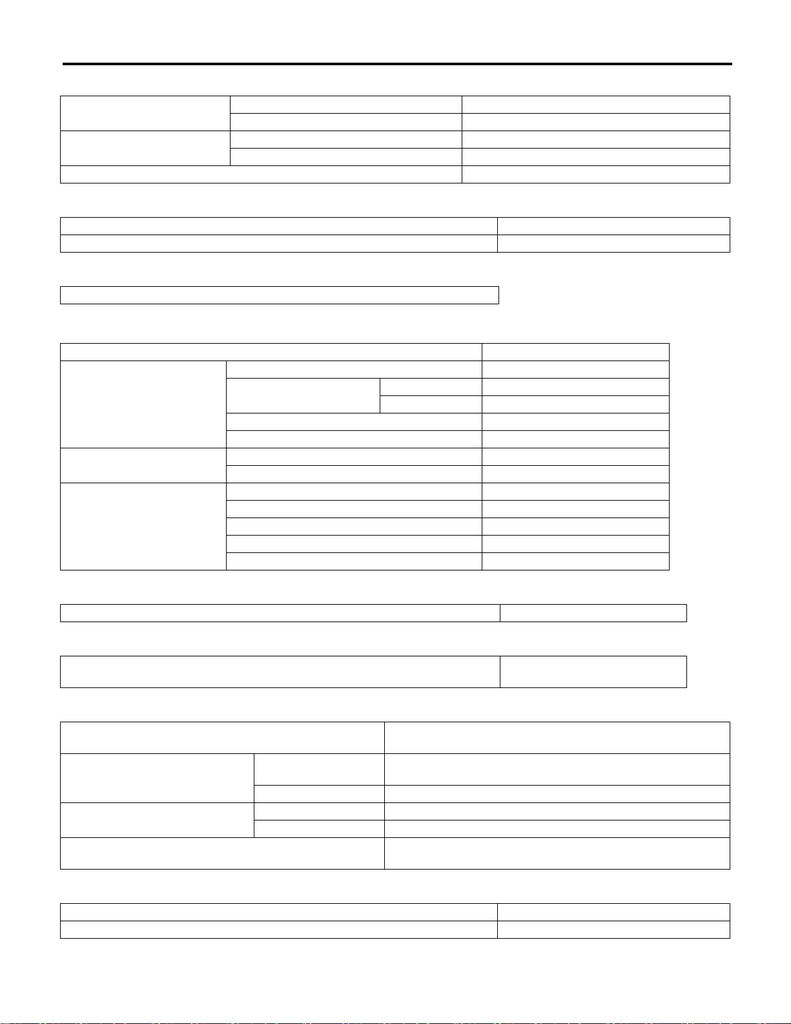

PS-3

General Description

POWER ASSISTED SYSTEM (POWER STEERING)

Power steering oil pump

Steering effort (with power steering assist)

Recommended power steering fluid

2. ELECTRIC TYPE

Steering wheel

Column assembly - steering

Steering gearbox

Steering effort (with power steering assist)

Pulley shaft

Lateral play: mm (in) 0.2 (0.008) or less

Axial play: mm (in) 0.9 (0.035) or less

Pulley

Groove runout: mm (in) 1.0 (0.039) or less

Rotational resistance: N (kgf, lbf) 9.22 (0.94, 2.07) or less

Regular pressure (unloaded): kPa (kgf/cm

2

, psi) 981 (10, 142) or less

At standstill on paved road with engine idling: N (kgf, lbf) 31 (3.16, 7.0) or less

At standstill on paved road with engine stalled: N (kgf, lbf) 294.2 (29.9, 66.2) or less

SUBARU ATF or ATF DEXRON III

Model WRX model

Whole system

Minimum turning radius: m (ft) 5.4 (17.72)

Steering angle

Inner wheel 37.5°±1.5°

Outer wheel 32.9°±1.5°

Steering wheel diameter: mm (in) 369 (14.53)

Lock-to-lock revolution number 2.8

Gearbox

Type Rack & pinion type

Backlash 0 (automatic adjusting)

Motor

(Temperature 20°C (68°F))

Rated voltage: V 12

Rated torque: N·m (kgf-m, ft-lb) 5.3 (0.54, 3.91)

Rated revolution speed: rpm 960

Rated current: A 84

Rated output: W 537

Free play: mm (in) 17 (0.67) or less

Clearance:

Between steering wheel and cover assembly - column

mm (in) 4 — 6 (0.16 — 0.24)

Sliding resistance: N (kgf, lbf)

360 (37, 81) or less

Difference between right and left sliding resistance: 20% or less

Rack shaft play in radial direction:

mm (in)

Right-turn steering

Play in the horizontal direction: 0.6 (0.024) or less

Play in the vertical direction: 0.4 (0.016) or less

Left-turn steering 0.4 (0.016) or less

Input shaft play: mm (in)

In radial direction 0.18 (0.0071) or less

In axial direction 0.27 (0.0106) or less

Rotational resistance: N (kgf, lbf)

Maximum allowable value: 18 (1.8, 4.0) or less

Difference between right and left sliding resistance: 20% or less

At standstill on paved road with engine idling: N (kgf, lbf) 31 (3.2, 7.0) or less

At standstill on paved road with engine stalled: N (kgf, lbf) 294.2 (30, 66.2) or less

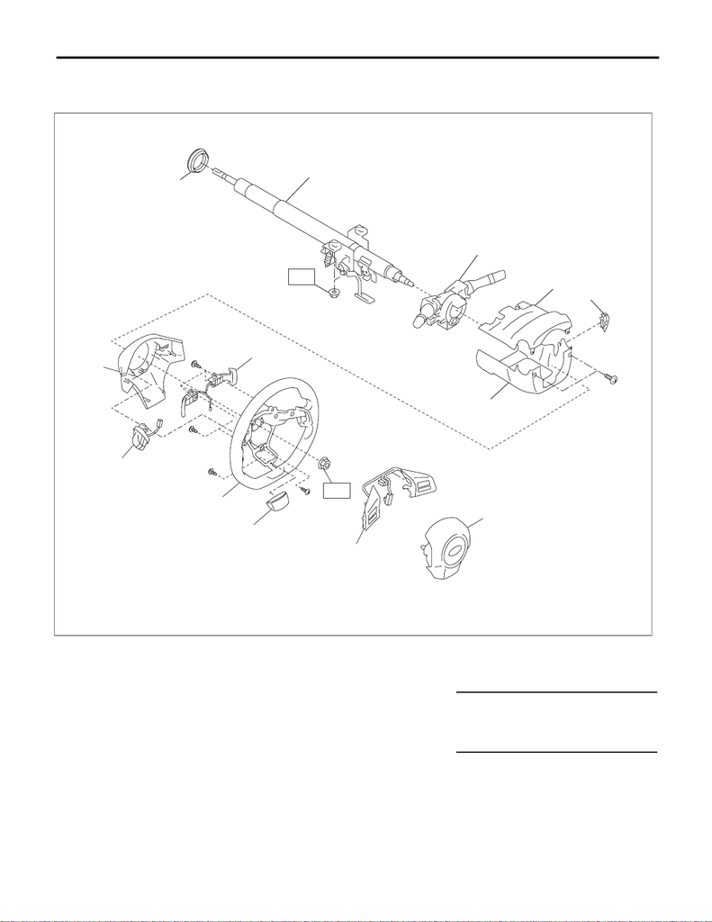

PS-4

General Description

POWER ASSISTED SYSTEM (POWER STEERING)

B: COMPONENT

1. STEERING WHEEL AND COLUMN

(1) Bushing (7) Cover - steering wheel LWR (13) Airbag module

(2) Column ASSY - steering (8) MID switch (multi-information dis-

play switch)

(3) Switch ASSY - combination (9) Paddle shift Tightening torque: N·m (kgf-m, ft-lb)

(4) Cover ASSY - column UPR (10) Steering wheel T1: 20 (2.0, 14.8)

(5) Cap - key cylinder (model with

keyless access)

(11) Cover - spoke T2: 39 (4.0, 28.8)

(6) Cover ASSY - column LWR (12) Satellite switch

PS-01745

(10)

T2

(9)

(11)

(8)

(7)

(12)

(13)

(3)

(4)

(5)

(6)

T1

(2)

(1)

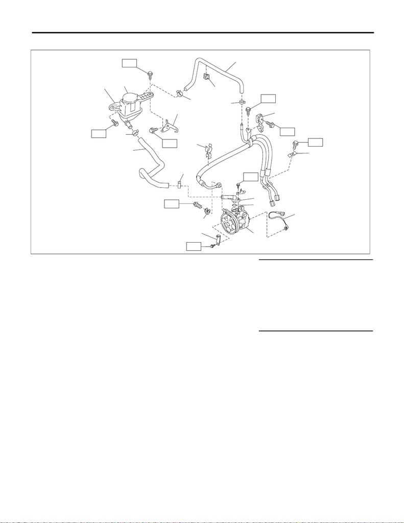

PS-5

General Description

POWER ASSISTED SYSTEM (POWER STEERING)

2. HOSE AND TANK

(1) Reservoir tank (10) Suction connector Tightening torque: N·m (kgf-m, ft-lb)

(2) Cap (11) O-ring T1: 7.5 (0.8, 5.5)

(3) Tank bracket (12) Oil pump T2: 10 (1.0, 7.4)

(4) Clip (13) Clip T3: 11 (1.1, 8.1)

(5) Hose clip (14) Eyebolt gasket T4: 13 (1.3, 9.6)

(6) Return hose (15) Bracket - belt cover T5: 18 (1.8, 13.3)

(7) Bracket - hose (16) Hose - suction T6: 33 (3.4, 24.3)

(8) Clamp E T7: 40 (4.1, 29.5)

(9) Switch - harness

PS-01726

(1)

(2)

T4

(4)

T4

T2

T5

T1

(16)

(6)

(13)

(7)

(9)

(15)

(4)

(14)

(8)

(4)

(4)

(5)

(3)

T3

(11)

(12)

(10)

T2

T7

T6

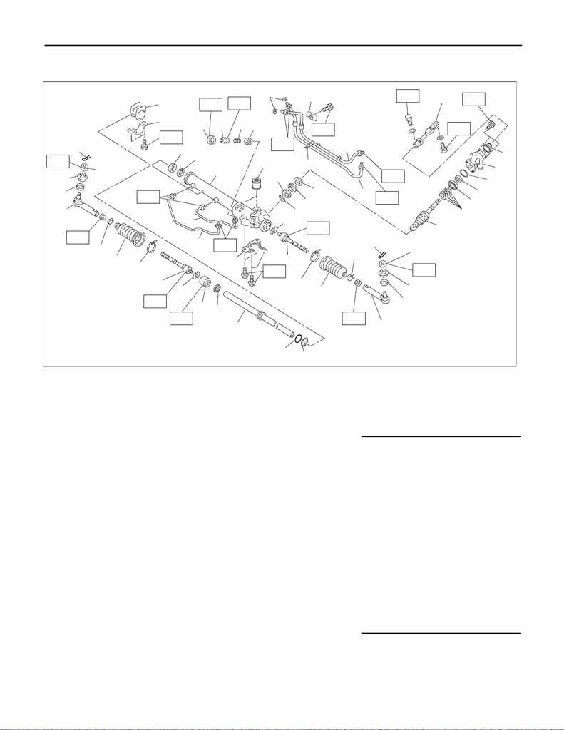

PS-6

General Description

POWER ASSISTED SYSTEM (POWER STEERING)

3. STEERING GEARBOX

• Hydraulic type

(1) Feed pipe (21) Clamp (41) Bushing

(2) Return pipe (22) Cotter pin (42) Lock washer

(3) Clamp plate (23) Castle nut (43) Back-up ring

(4) Universal joint (24) Dust cover (44) O-ring

(5) Dust seal (25) Clip

(6) Valve housing (26) Tie-rod end Tightening torque: N·m (kgf-m, ft-lb)

(7) O-ring (27) Clip T1: Tighten to 5.9 (0.6, 4.4), and

loosen by 5 degrees.

(8) Oil seal (28) Boot T2: 9 (0.9, 6.6)

(9) Bushing (29) Band T3: 15 (1.5, 11.1)

(10) Seal ring (30) Tie-rod T4: 17 (1.7, 12.5)

(11) Pinion & valve ASSY (31) Pipe B T5: 20 (2.0, 14.8)

(12) Oil seal (32) Pipe A T6: 24 (2.4, 17.7)

(13) Back-up washer (33) Steering body T7: 25 (2.5, 18.4)

(14) Ball bearing (34) Oil seal T8: 27 (2.8, 19.9)

(15) Snap ring (35) Piston seal ring T9: 37 (3.8, 27.3)

(17) Adjusting screw (37) Oil seal T11: 60 (6.1, 44.3)

(18) Spring (38) Holder T12: 70 (7.1, 51.6)

(19) Sleeve (39) O-ring T13: 85 (8.7, 62.7)

(20) Adapter (40) Stiffener T14: 93 (9.5, 68.6)

T11

T8

T13

T8

T14

T4

T14

T13

T8

T5

T6

(22)

(20)

(23)

(24)

(25)

(26)

(27)

(28)

(29)

(30)

(38)

(37)

(32)

(36)

(35)

(44)

(30)

(28)

(27)

(26)

(25)

(24)

(7)

(8)

(9)

(10)

(11)

(22)

(23)

(5)

(6)

(12)

(13)

(15)

(42)

(42)

(14)

(33)

(19)

(18)

(17)

(16)

(21)

(34)

(31)

T3

(2)

(3)

T9

T10

T2

(1)

(3)

(39)

T7

T1

(29)

(40)

T11

(41)

T12

(43)

PS-01756

T6

(4)

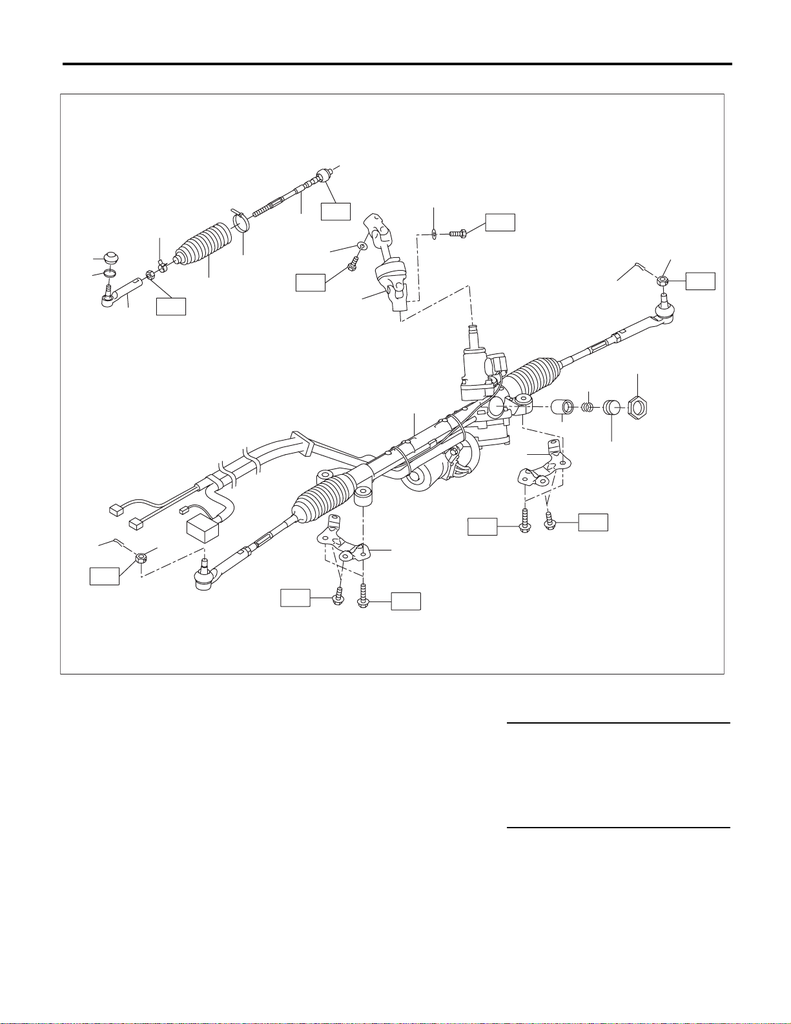

PS-7

General Description

POWER ASSISTED SYSTEM (POWER STEERING)

• Electric type

(1) Dust seal (9) Universal joint ASSY - steering (17) Cotter pin

(2) Clip - boot tie-rod end (10) Castle nut

(3) Tie-rod end (11) Stiffener Tightening torque: N·m (kgf-m, ft-lb)

(4) Clip - boot tie-rod (12) Steering gearbox ASSY T1: 24 (2.4, 17.7)

(5) Boot - steering gearbox (13) Pad - pressure T2: 27 (2.8, 19.9)

(6) Band - boot (14) Spring - gearbox T3: 60 (6.1, 44.3)

(7) Tie-rod (15) Adjusting screw T4: 85 (8.7, 62.7)

(8) Spring washer (16) Lock nut T5: 90 (9.2, 66.4)

T1

(10)

(8)

(8)

(9)

(7)

(6)

(12)

(11)

(10)

(13)

(14)

(15)

(16)

(5)

(4)

(3)

(1)

(11)

(17)

(2)

T4

T5

T2

T1

T2

T3

T3

T3

T3

PS-01473

(17)

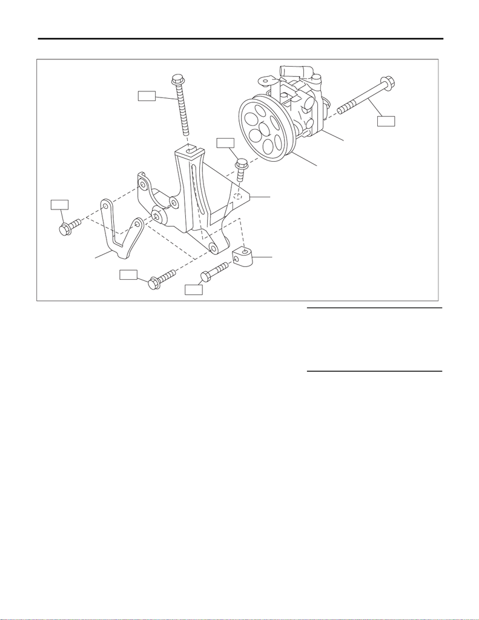

PS-8

General Description

POWER ASSISTED SYSTEM (POWER STEERING)

4. OIL PUMP

(1) Oil pump Tightening torque: N·m (kgf-m, ft-lb)

(2) Pulley T1: 8 (0.8, 5.9)

(3) Bracket T2: 16 (1.6, 11.8)

(4) Belt tension nut T3: 22 (2.2, 16.2)

(5) Washer plate T4: 25 (2.5, 18.4)

T5: 48 (4.9, 35.4)

T4

T3

T3

T5

T1

T2

(3)

(2)

(1)

(4)

PS-01679

(5)

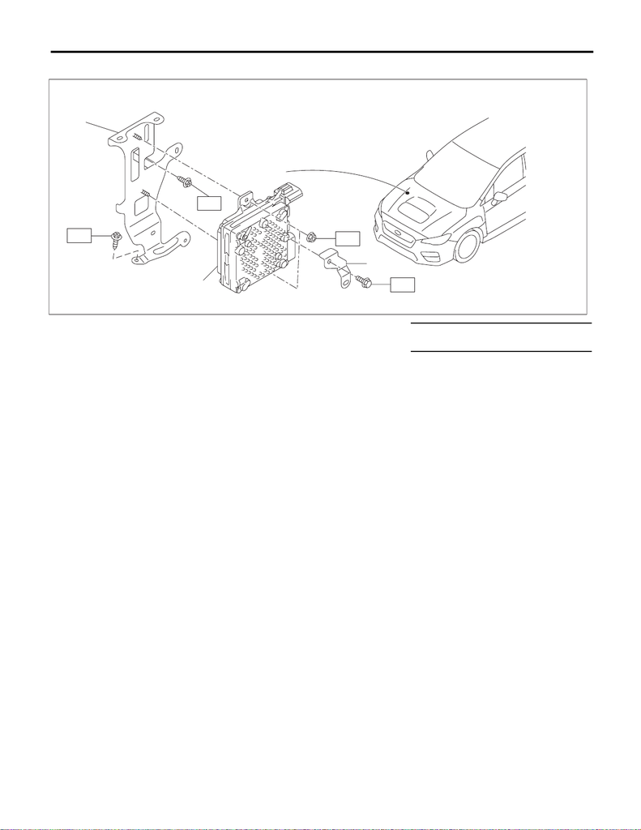

PS-9

General Description

POWER ASSISTED SYSTEM (POWER STEERING)

5. ELECTRIC POWER STEERING CONTROL MODULE

C: CAUTION

• When performing any work, always wear work clothes, a work cap and protective shoes. Additionally, wear

a helmet, protective goggles, etc. if necessary.

• When performing a repair, identify the cause of trouble and avoid unnecessary removal, disassembly and

replacement.

• Some vehicle components are extremely hot immediately after driving. Be wary of receiving burns from

heated parts.

• Use SUBARU genuine grease, the recommended or equivalent. Do not mix grease etc. of different grades

or manufacturers.

• Be sure to tighten fasteners including bolts and nuts to the specified torque.

• Always use the jack-up point when the shop jacks or rigid racks are used to support the vehicle.

• Do not secure a part in a vise directly. Place cushioning materials such as wood blocks, aluminum plates,

or waste cloth between the part and the vise.

• When removing, installing or replacing the VDCCM&H/U, VDCCM&H/U bracket, steering wheel or steer-

ing angle sensor (steering roll connector), perform “VDC sensor midpoint setting mode” of the VDC. <Ref. to

VDC-16, VDC SENSOR MIDPOINT SETTING MODE, ADJUSTMENT, VDC Control Module and Hydraulic

Control Unit (VDCCM&H/U).>

(1) Bracket - control module (3) Harness bracket Tightening torque: N·m (kgf-m, ft-lb)

(2) Power steering control module T: 7.5 (0.8, 5.5)

PS-01737

T

T

T

T

(1)

(2)

(3)

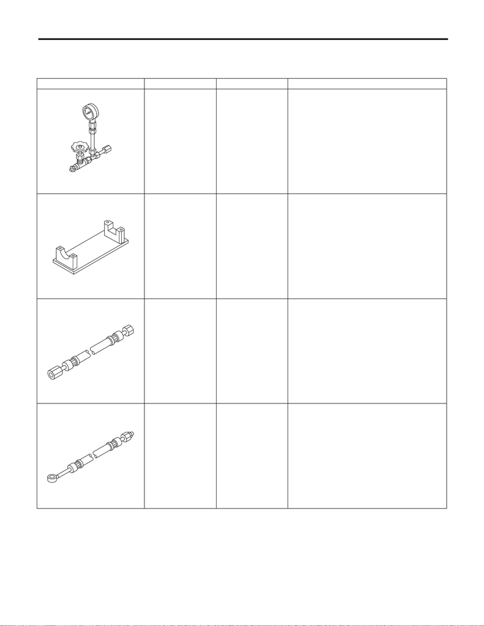

PS-10

General Description

POWER ASSISTED SYSTEM (POWER STEERING)

D: PREPARATION TOOL

1. SPECIAL TOOL

ILLUSTRATION TOOL NUMBER DESCRIPTION REMARKS

925711000 PRESSURE

GAUGE

Used for measuring oil pressure.

926200000 STAND • Used when inspecting characteristic of gear-

box assembly and disassembling it.

• Used together with BOSS D (34199AG000).

34099AC010 ADAPTER HOSE A Used together with PRESSURE GAUGE

(925711000).

34099AC020 ADAPTER HOSE B Used together with PRESSURE GAUGE

(925711000).

ST-925711000

ST-926200000

ST34099AC010

ST34099AC020

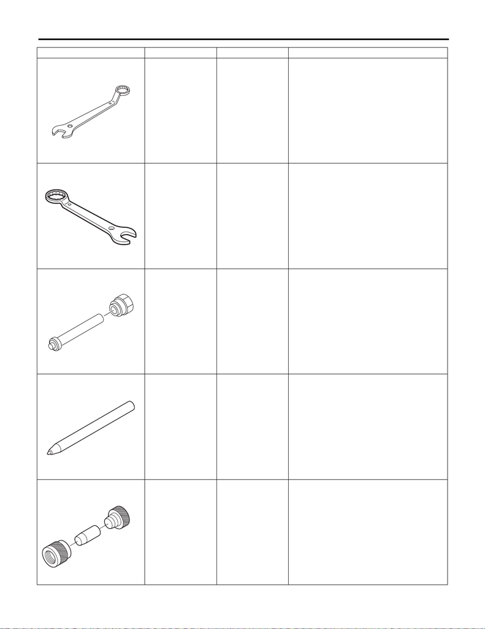

PS-11

General Description

POWER ASSISTED SYSTEM (POWER STEERING)

926230000 SPANNER For the lock nut when adjusting backlash of gear-

box.

34099PA100 SPANNER Used when measuring the rotational resistance

of gearbox assembly.

926420000 PLUG When fluid leaks from pinion side of gearbox

assembly, remove pipe B from valve housing,

attach this tool and check fluid leaking points.

34099FA060 PUNCH HOLDER Used for crimping.

34199FE040 INSTALLER A, B, C • Used for installing the oil seal to the rack

assembly.

• INSTALLER A: 34199FE070

• INSTALLER B: 34199FE080

• INSTALLER C: 34199FE090

ILLUSTRATION TOOL NUMBER DESCRIPTION REMARKS

ST-926230000

ST34099PA100

ST-926420000

ST34099FA060

ST34199FE040

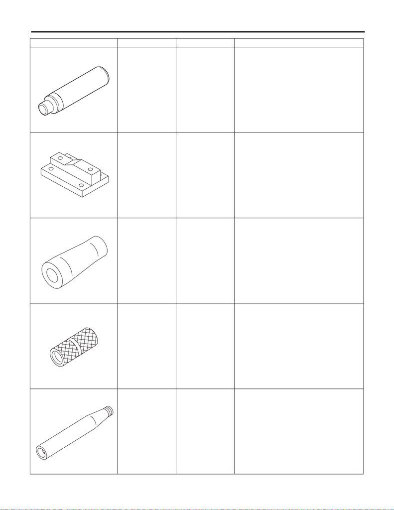

PS-12

General Description

POWER ASSISTED SYSTEM (POWER STEERING)

34199XA030 INSTALLER &

REMOVER

Used for removing and installing the rack oil seal

(outer and inner).

34199AG000 BOSS D • Used when inspecting characteristic of gear-

box assembly and disassembling it.

• Used together with STAND (926200000).

34199AG040 GUIDE Used for installing seal ring of rack.

34199AG070 FORMER Used for forming seal ring of pinion.

34199AG020 GUIDE Used for installing seal ring of pinion.

ILLUSTRATION TOOL NUMBER DESCRIPTION REMARKS

ST34199XA030

ST34199AG000

ST34199AG040

ST34199AG070

ST34199AG020

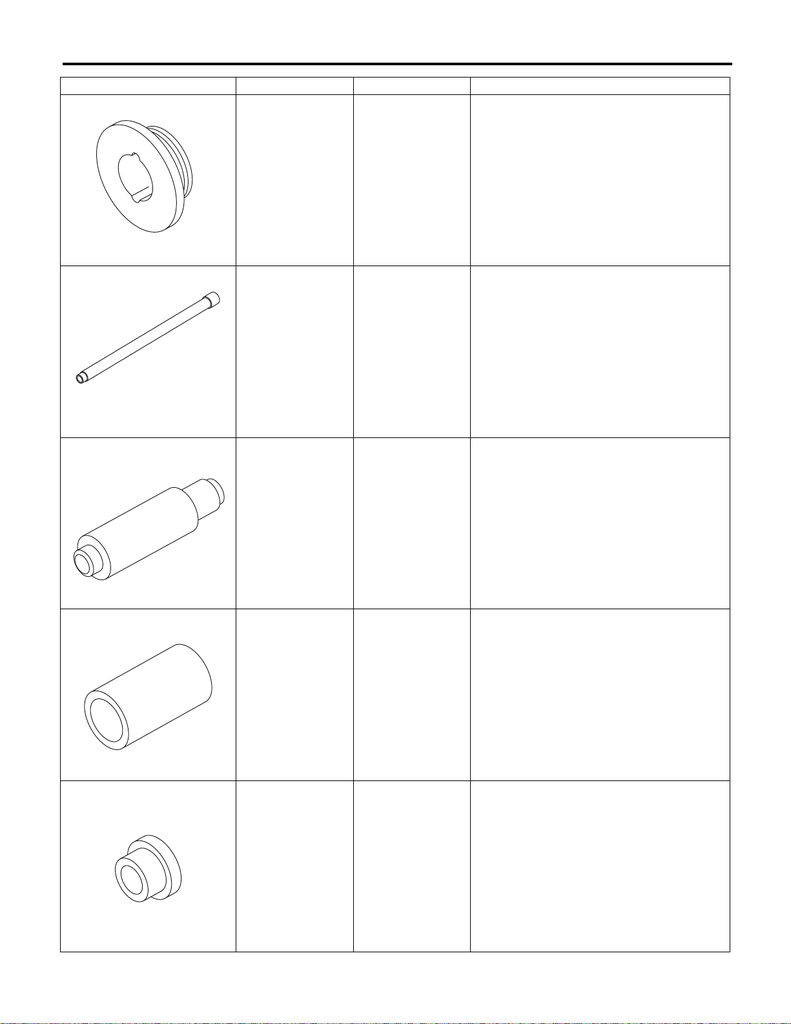

PS-13

General Description

POWER ASSISTED SYSTEM (POWER STEERING)

34199AG060 GUIDE G (26) • Used for forming seal ring of rack.

• Used together with FORMER PISTON

(34199AG080).

34099PA010 OIL SEAL

REMOVER

Used for removing oil seal.

34199AG090 INSTALLER &

REMOVER

• Used for installing oil seal of valve housing.

• Used for installing ball bearing of valve hous-

ing.

• Used for removing oil seal and ball bearing

from valve housing.

34199AG080 FORMER PISTON • Used for forming seal ring of rack.

• Used together with GUIDE G (26)

(34199AG060).

34199AG010 INSTALLER Used for pressing-fit oil seal of gearbox cylinder.

ILLUSTRATION TOOL NUMBER DESCRIPTION REMARKS

ST34199AG060

ST34099PA010

ST34199AG090

ST34199AG080

ST34199AG010

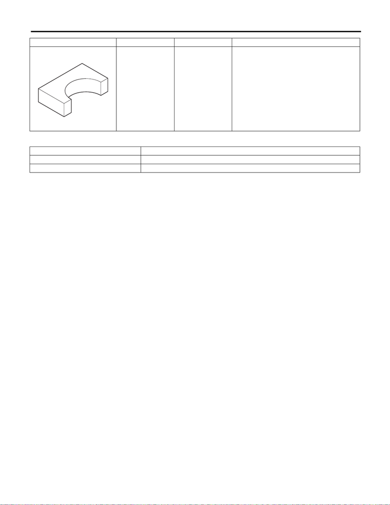

PS-14

General Description

POWER ASSISTED SYSTEM (POWER STEERING)

2. GENERAL TOOL

34199FE020 BASE Used for crimping.

TOOL NAME REMARKS

Steering wheel puller Used for removing the steering wheel.

Circuit tester Used for measuring voltage and resistance.

ILLUSTRATION TOOL NUMBER DESCRIPTION REMARKS

ST34199FE020